# Analysis Football Gambling Study

Henrik

18 February, 2021

# Preparation

## Load & Prepare Data

We first load in the data from all participants and transform variables into correct type. We also perform some checks on the data to confirm that it matches our expectations (i.e., in size and structure).

Then we create the our DV, proportion bet, as follows (note that the initial endowment was £3):
$$\texttt{prop_bet} = \frac{\texttt{amount bet}}{3}$$

The analysis is based on the following number of participants

```
## [1] 1003
```

```
## # A tibble: 2 x 2
##   condition     n
##   <fct>     <int>
## 1 None        501
## 2 Yellow      502
```

# Distribution of DV

Our DV clearly does not look normally distributed and shows some clear bump at certain prominent numbers.

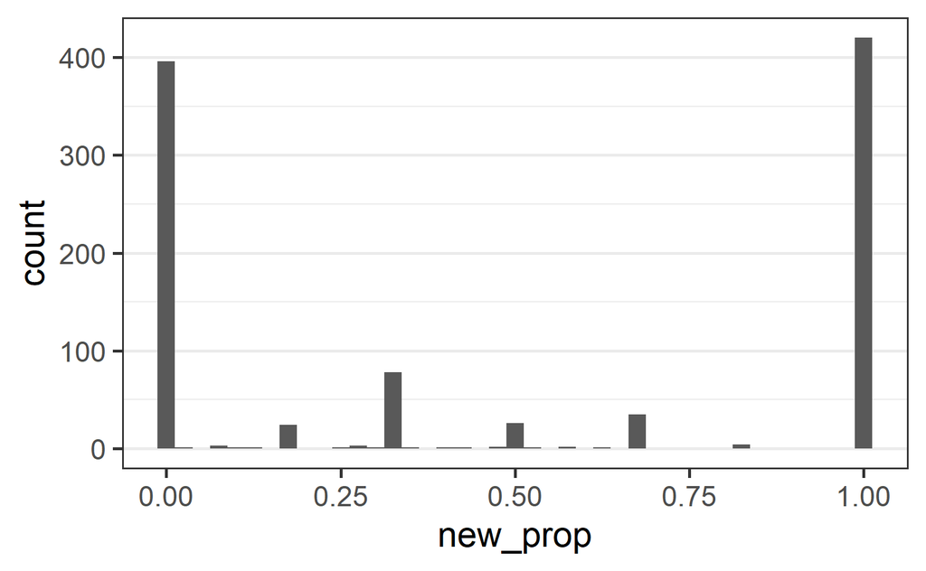

Binomial confidence or credibility intervals for the probability to gamble at all:

```
##           method   x    n      mean     lower     upper
## 1  agresti-coull 608 1003 0.6061815 0.5755911 0.6359616
## 2     asymptotic 608 1003 0.6061815 0.5759439 0.6364190
## 3          bayes 608 1003 0.6060757 0.5758157 0.6362173
## 4        cloglog 608 1003 0.6061815 0.5752055 0.6356554
## 5          exact 608 1003 0.6061815 0.5751698 0.6365680
## 6          logit 608 1003 0.6061815 0.5755731 0.6359785
## 7         probit 608 1003 0.6061815 0.5756531 0.6360706
## 8        profile 608 1003 0.6061815 0.5757014 0.6361198
## 9            lrt 608 1003 0.6061815 0.5757042 0.6361101
## 10     prop.test 608 1003 0.6061815 0.5750905 0.6364488
## 11        wilson 608 1003 0.6061815 0.5755938 0.6359589
```

# Zero-One Inflated Beta Regression

We use a custom parameterization of a zero-one-inflated beta-regression model (see also [here](https://vuorre.netlify.com/post/2019/02/18/analyze-analog-scale-ratings-with-zero-one-inflated-beta-models/)). The likelihood of the model is given by:

$$\begin{align}
f(y) &= (1 - g) & & \text{if } y = 0 \\
f(y) &= g \times e & & \text{if } y = 1 \\
f(y) &= g \times (1 - e) \times \text{Beta}(a,b) & & \text{if } y \notin \{0, 1\} \\
a &= \mu \times \phi \\
b &= (1-\mu) \times \phi
\end{align}$$

Where $g$ is the zero inflation probability (`zipp`) and reflects the probability to gamble, $e$ is the conditional one-inflation probability (`coi`) or conditional probability to gamble everything (i.e., conditional probability to have a value of one, if one gambles), $\mu$ is the mean of the beta distribution (`Intercept`), and $\phi$ is the precision of the beta distribution (`phi`). As we use `Stan` for modelling, we need to model on the real line and need appropriate link functions. For `\phi` the link is log (inverse is `exp()`), for all other parameters it is logit (inverse is `plogis()`).

We fit this model and add experimental condition as a factor to the three main model parameters (i.e., only the precision parameter is fixed across conditions). The following table provides the overview of the model and all model parameters and show good convergence.

```
##  Family: zoib2
##   Links: mu = logit; phi = log; zipp = logit; coi = logit
## Formula: new_prop ~ condition
##          phi ~ 1
##          zipp ~ condition
##          coi ~ condition
##    Data: part2 (Number of observations: 1003)
## Samples: 4 chains, each with iter = 26000; warmup = 1000; thin = 1;
##          total post-warmup samples = 1e+05
##
## Population-Level Effects:
##                      Estimate Est.Error l-95% CI u-95% CI Rhat Bulk_ESS Tail_ESS
## Intercept               -0.39      0.08    -0.53    -0.24 1.00   165326    79648
## phi_Intercept            1.80      0.10     1.60     1.98 1.00   156811    76279
## zipp_Intercept           0.41      0.09     0.23     0.59 1.00   162053    78870
## coi_Intercept            0.67      0.12     0.43     0.91 1.00   158057    76842
## conditionYellow         -0.02      0.11    -0.24     0.20 1.00   153942    77003
## zipp_conditionYellow     0.05      0.13    -0.21     0.30 1.00   162122    76877
## coi_conditionYellow      0.28      0.18    -0.07     0.62 1.00   151240    75525
##
## Samples were drawn using sampling(NUTS). For each parameter, Bulk_ESS
## and Tail_ESS are effective sample size measures, and Rhat is the potential
## scale reduction factor on split chains (at convergence, Rhat = 1).
```

As a visual convergence check, we plot the density and trace plots for the four intercept parameters representing the no message condition or the overall mean (for `phi`).

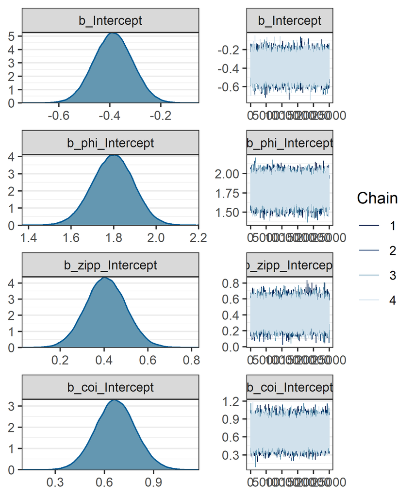

We can also plot the three parameters showing the difference distribution of the message condition from the no message condition. These differences are given on the logit scale.

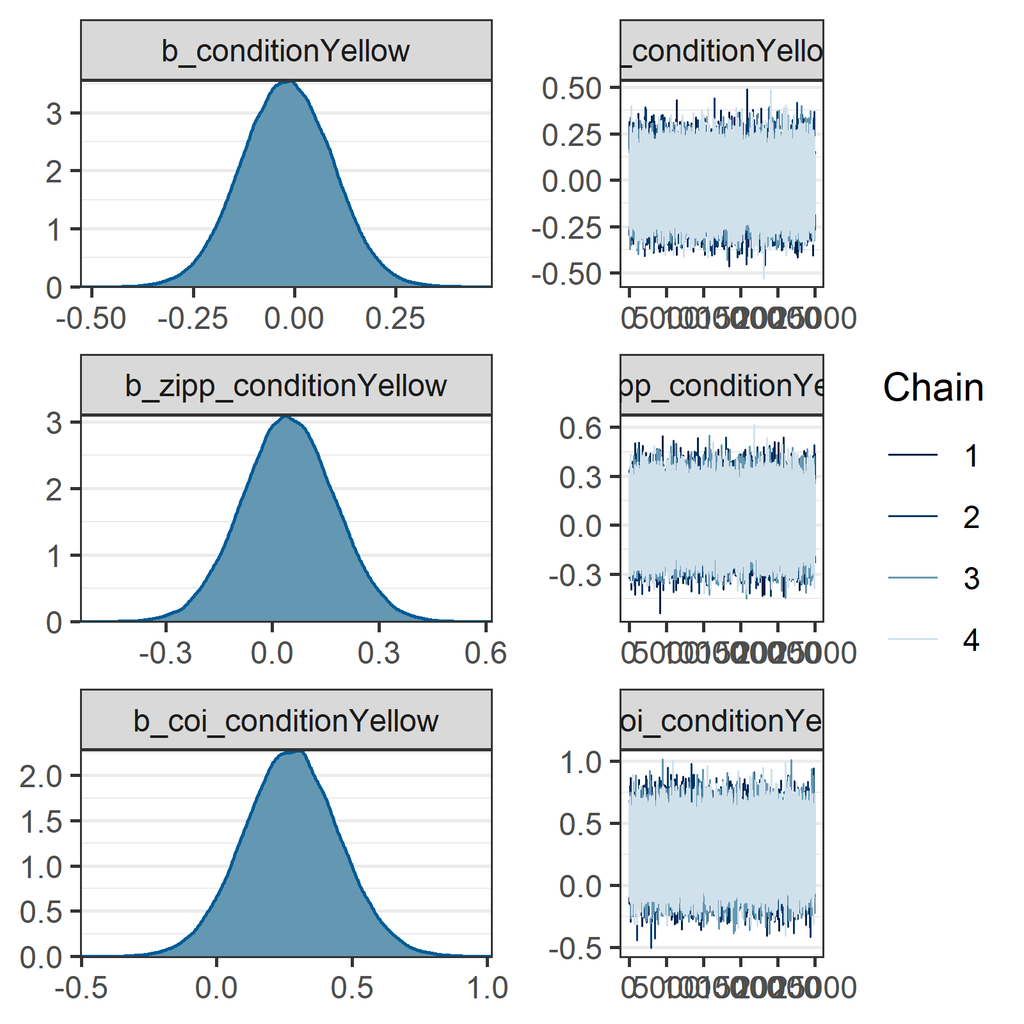

The model does not have any obvious problems, even without priors for the condition specific effects.

## Posterior Predictive Checks

As expected the synthetic data generated from the model is able to adequately predict the two peaks at the boundary, but does not fully capture the peaks in between those. However, the mass of the distribution between the peaks seems to be at a similar location in both the observed and the synthetic data.

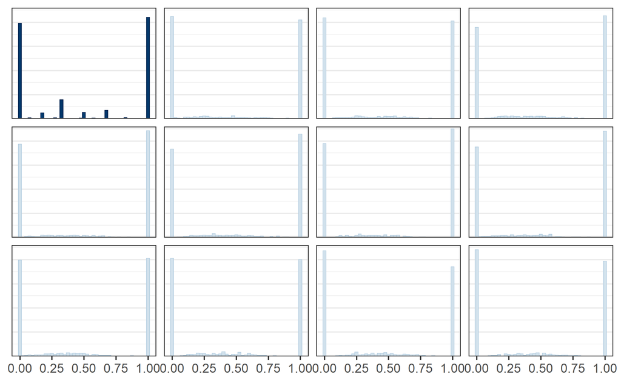

## Model Estimates

We first give the table showing the posterior means and 95% CIs.

```
## # A tibble: 6 x 8
## # Groups:   parameter [3]
##   parameter          condition estimate .lower .upper .width .point .interval
##   <fct>              <chr>        <dbl>  <dbl>  <dbl>  <dbl> <chr>  <chr>
## 1 Gamble at all?     None         0.600  0.557  0.643   0.95 mean   qi
## 2 Gamble at all?     Yellow       0.611  0.569  0.653   0.95 mean   qi
## 3 Gamble everything? None         0.661  0.606  0.713   0.95 mean   qi
## 4 Gamble everything? Yellow       0.719  0.668  0.768   0.95 mean   qi
## 5 Proportion bet?    None         0.405  0.370  0.441   0.95 mean   qi
## 6 Proportion bet?    Yellow       0.400  0.362  0.439   0.95 mean   qi
```

For the zero-one inflated components, we can compare the model estimates with the data. Not unsurprisingly, they match quite well.

```
## # A tibble: 2 x 3
##   condition gamble_at_all gamble_everything
##   <fct>             <dbl>             <dbl>
## 1 None              0.601             0.661
## 2 Yellow            0.612             0.720
```

The following is the main results figure on the level of the message conditions.

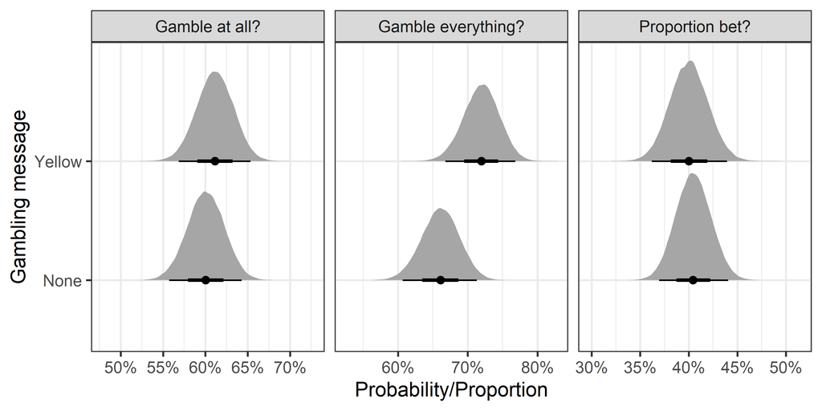

## Difference distribution versus no message condition

We can also focus and look at the difference distributions from the no message condition.

```
## # A tibble: 6 x 8
## # Groups:   parameter [3]
##   parameter          condition    estimate  .lower .upper .width .point .interval
##   <fct>              <fct>           <dbl>   <dbl>  <dbl>  <dbl> <chr>  <chr>
## 1 Gamble at all?     "          "  0.0108  -0.0285 0.0504   0.8  mean   qi
## 2 Gamble everything? "          "  0.0587   0.0112 0.106    0.8  mean   qi
## 3 Proportion bet?    "          " -0.00442 -0.0386 0.0297   0.8  mean   qi
## 4 Gamble at all?     "          "  0.0108  -0.0494 0.0712   0.95 mean   qi
## 5 Gamble everything? "          "  0.0587  -0.0144 0.132    0.95 mean   qi
## 6 Proportion bet?    "          " -0.00442 -0.0565 0.0477   0.95 mean   qi
```

Same as a figure.

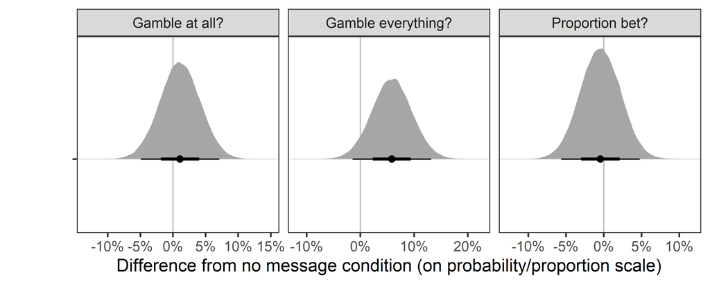

## Difference Distributions with Possible Priors

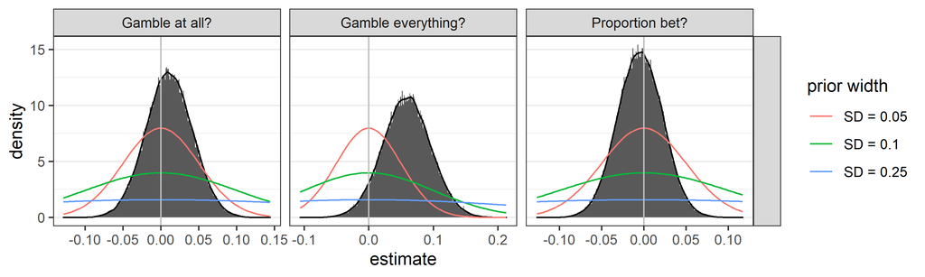

# Model With Covariates

The covariates do not differ between conditions (BF provide evidence for the null).

```
## Bayes factor analysis
## --------------
## [1] Intercept only : 5.980854 ±0.01%
##
## Against denominator:
##   pgsi ~ condition
## ---
## Bayes factor type: BFlinearModel, JZS
```

```
## Bayes factor analysis
## --------------
## [1] Intercept only : 2.146103 ±0%
##
## Against denominator:
##   motives ~ condition
## ---
## Bayes factor type: BFlinearModel, JZS
```

The following table shows descriptives for the covariates:

```
## # A tibble: 2 x 5
##   condition pgsi_mean pgsi_sd motives_mean motives_sd
##   <fct>         <dbl>   <dbl>        <dbl>      <dbl>
## 1 None           2.12    3.84         5.23       3.66
## 2 Yellow         1.82    3.45         4.77       3.73
```

Correlation of covariates:

```
##
##  Pearson's product-moment correlation
##
## data:  pgsi and motives
## t = 12.228, df = 1001, p-value < 2.2e-16
## alternative hypothesis: true correlation is not equal to 0
## 95 percent confidence interval:
##  0.3054271 0.4131911
## sample estimates:
##       cor
## 0.3605115
```

## Model with Main Effects

```
##  Family: zoib2
##   Links: mu = logit; phi = log; zipp = logit; coi = logit
## Formula: new_prop ~ condition + pgsi_c + motives_c
##          phi ~ 1
##          zipp ~ condition + pgsi_c + motives_c
##          coi ~ condition + pgsi_c + motives_c
##    Data: part2 (Number of observations: 1003)
## Samples: 4 chains, each with iter = 26000; warmup = 1000; thin = 1;
##          total post-warmup samples = 1e+05
##
## Population-Level Effects:
##                      Estimate Est.Error l-95% CI u-95% CI Rhat Bulk_ESS Tail_ESS
## Intercept               -0.41      0.08    -0.56    -0.27 1.00   204638    78875
## phi_Intercept            1.83      0.10     1.63     2.02 1.00   199577    74920
## zipp_Intercept           0.41      0.09     0.22     0.59 1.00   223505    73569
## coi_Intercept            0.64      0.12     0.40     0.88 1.00   220411    77103
## conditionYellow          0.02      0.11    -0.19     0.24 1.00   199808    77825
## pgsi_c                  -0.02      0.02    -0.05     0.01 1.00   195904    82129
## motives_c                0.04      0.02     0.01     0.08 1.00   187119    82114
## zipp_conditionYellow     0.09      0.13    -0.17     0.35 1.00   214675    71246
## zipp_pgsi_c             -0.04      0.02    -0.08    -0.00 1.00   187697    84188
## zipp_motives_c           0.12      0.02     0.08     0.16 1.00   181763    86458
## coi_conditionYellow      0.30      0.18    -0.05     0.65 1.00   222578    75461
## coi_pgsi_c               0.01      0.03    -0.04     0.06 1.00   184080    79982
## coi_motives_c            0.05      0.03     0.00     0.11 1.00   186304    81217
##
## Samples were drawn using sampling(NUTS). For each parameter, Bulk_ESS
## and Tail_ESS are effective sample size measures, and Rhat is the potential
## scale reduction factor on split chains (at convergence, Rhat = 1).
```

As a visual convergence check, we plot the density and trace plots for the four intercept parameters representing the no message condition or the overall mean (for `phi`).

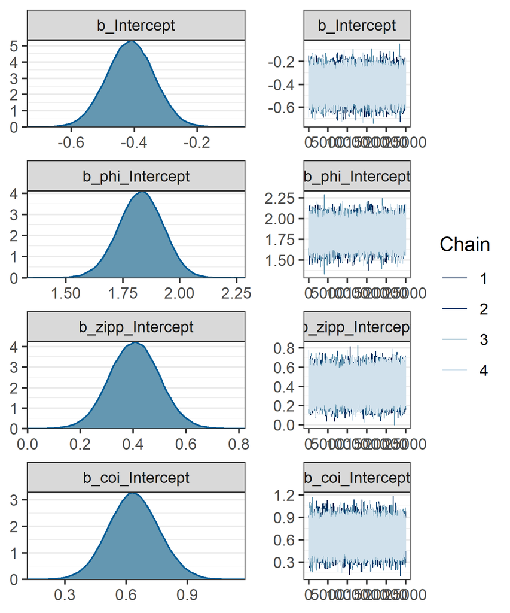

We can also plot the three parameters showing the difference distribution of the message condition from the no message condition. These differences are given on the logit scale.

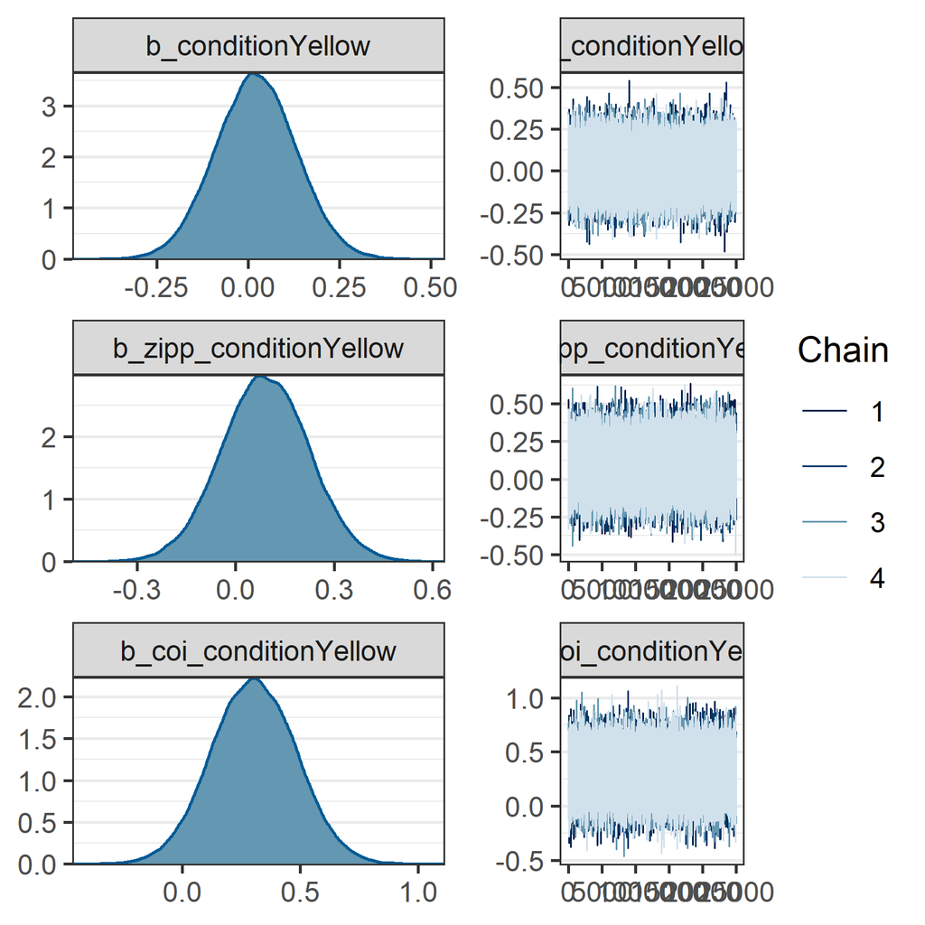

We also check the chains for the PGSI and motives scales.

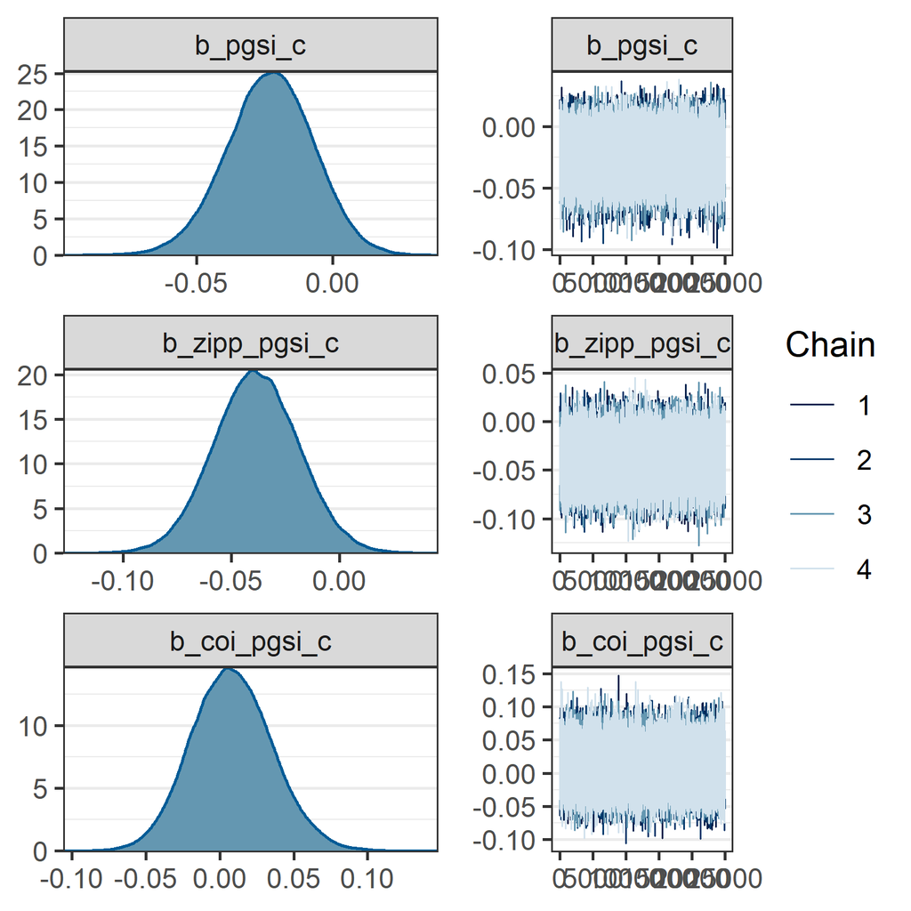

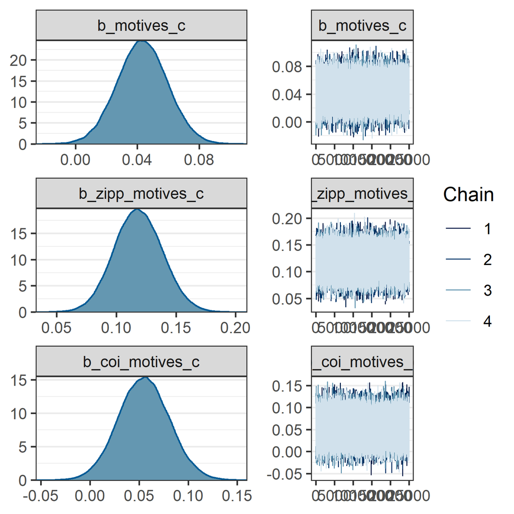

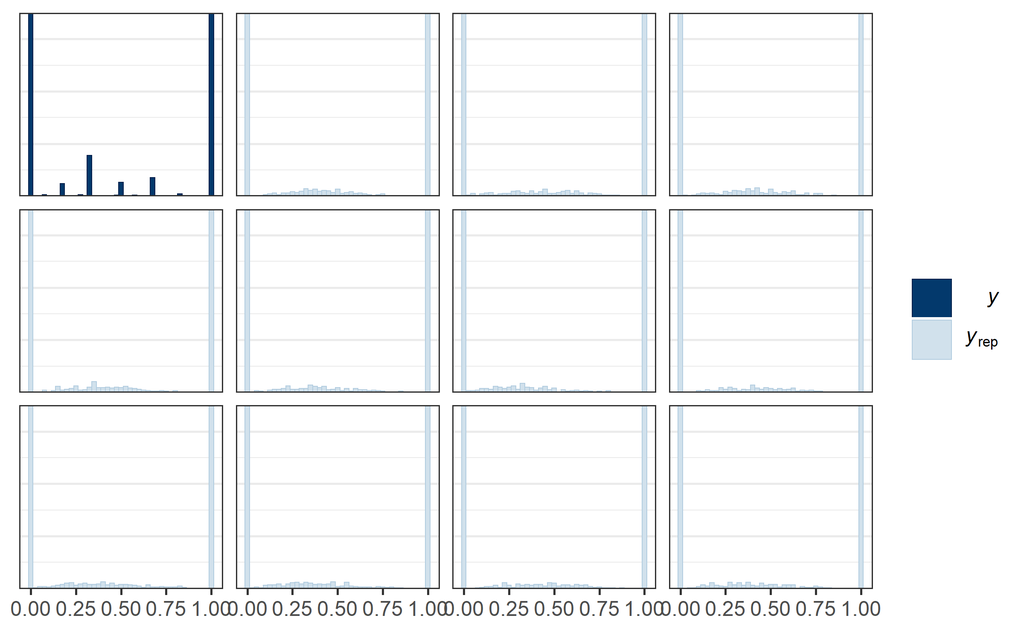

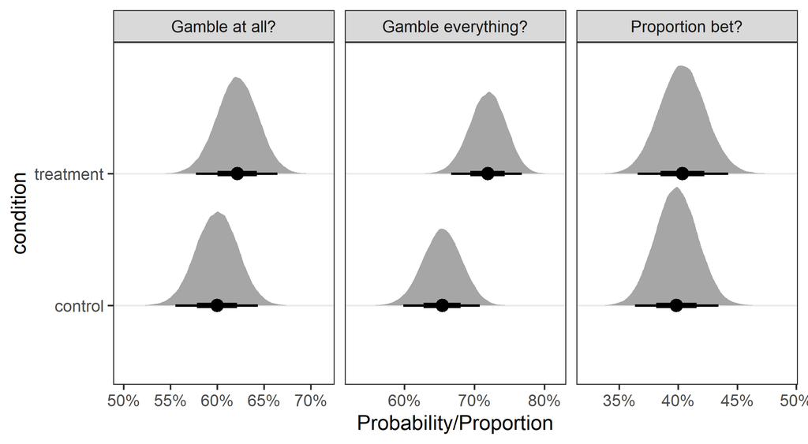

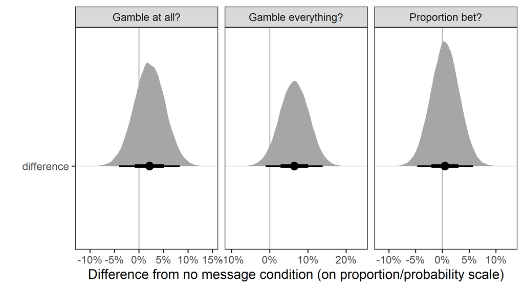

## Model with Main Effects (only PGSI)

```
##  Family: zoib2
##   Links: mu = logit; phi = log; zipp = logit; coi = logit
## Formula: new_prop ~ condition + pgsi_c
##          phi ~ 1
##          zipp ~ condition + pgsi_c
##          coi ~ condition + pgsi_c
##    Data: part2 (Number of observations: 1003)
## Samples: 4 chains, each with iter = 26000; warmup = 1000; thin = 1;
##          total post-warmup samples = 1e+05
##
## Population-Level Effects:
##                      Estimate Est.Error l-95% CI u-95% CI Rhat Bulk_ESS Tail_ESS
## Intercept               -0.39      0.08    -0.54    -0.24 1.00   188685    77974
## phi_Intercept            1.79      0.10     1.60     1.98 1.00   184659    77602
## zipp_Intercept           0.41      0.09     0.23     0.59 1.00   190736    77024
## coi_Intercept            0.67      0.12     0.43     0.91 1.00   196512    76475
## conditionYellow         -0.02      0.11    -0.24     0.20 1.00   192125    76321
## pgsi_c                  -0.01      0.02    -0.04     0.02 1.00   194361    75283
## zipp_conditionYellow     0.05      0.13    -0.21     0.30 1.00   194240    76896
## zipp_pgsi_c              0.00      0.02    -0.03     0.04 1.00   194850    79082
## coi_conditionYellow      0.28      0.18    -0.06     0.63 1.00   194609    77274
## coi_pgsi_c               0.03      0.03    -0.02     0.08 1.00   190892    75247
##
## Samples were drawn using sampling(NUTS). For each parameter, Bulk_ESS
## and Tail_ESS are effective sample size measures, and Rhat is the potential
## scale reduction factor on split chains (at convergence, Rhat = 1).
```

As a visual convergence check, we plot the density and trace plots for the four intercept parameters representing the no message condition or the overall mean (for `phi`).

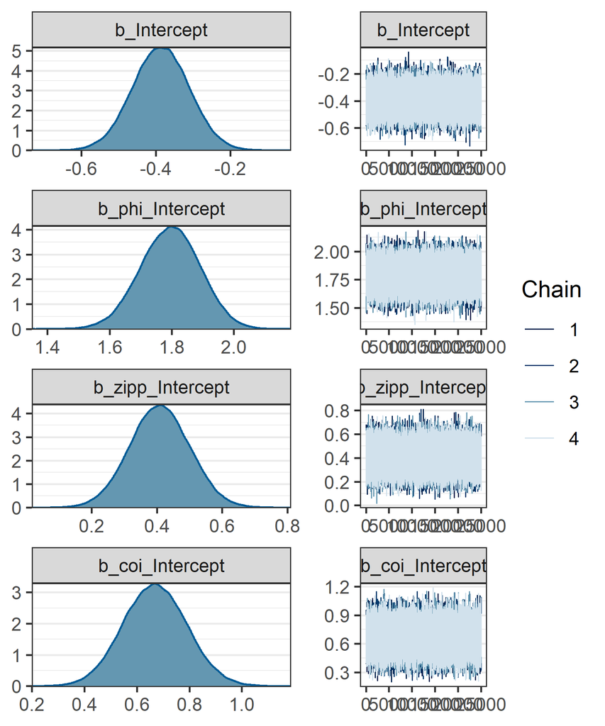

We can also plot the three parameters showing the difference distribution of the message condition from the no message condition. These differences are given on the logit scale.

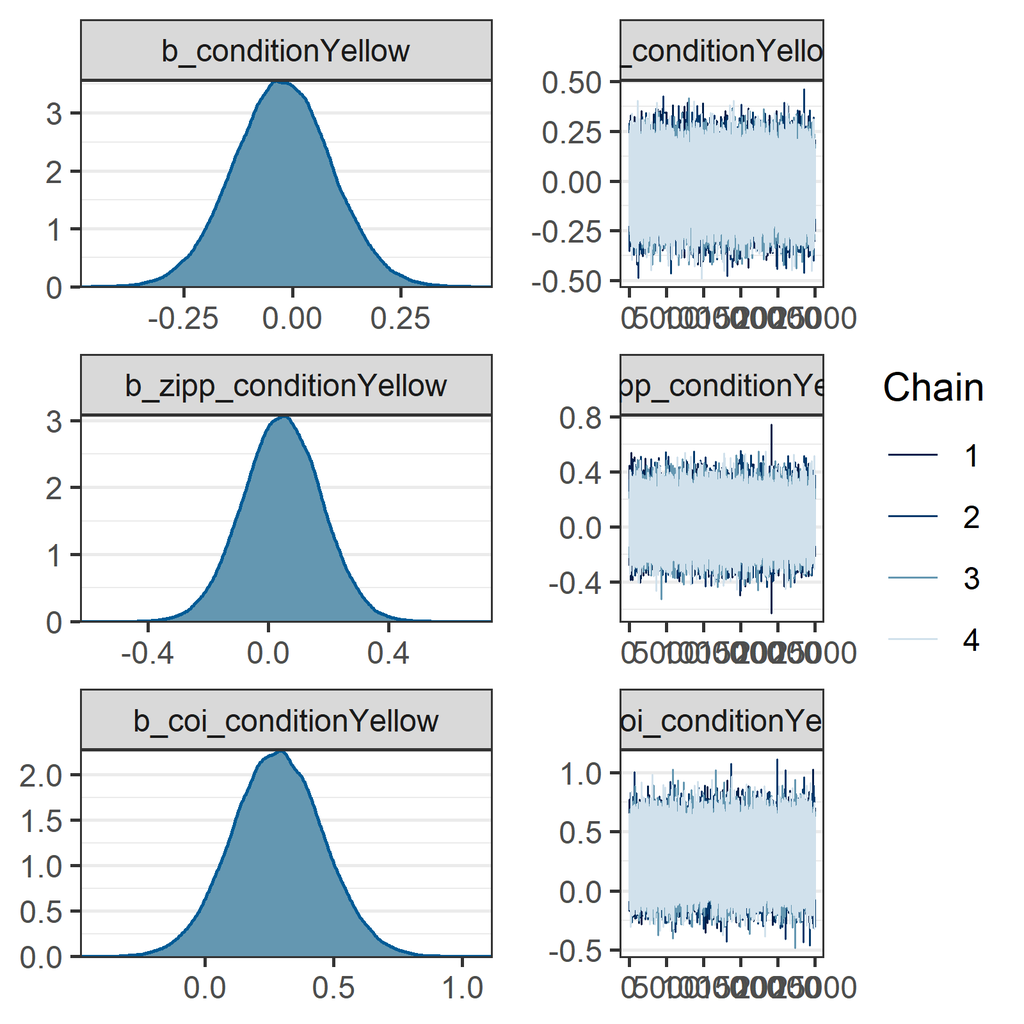

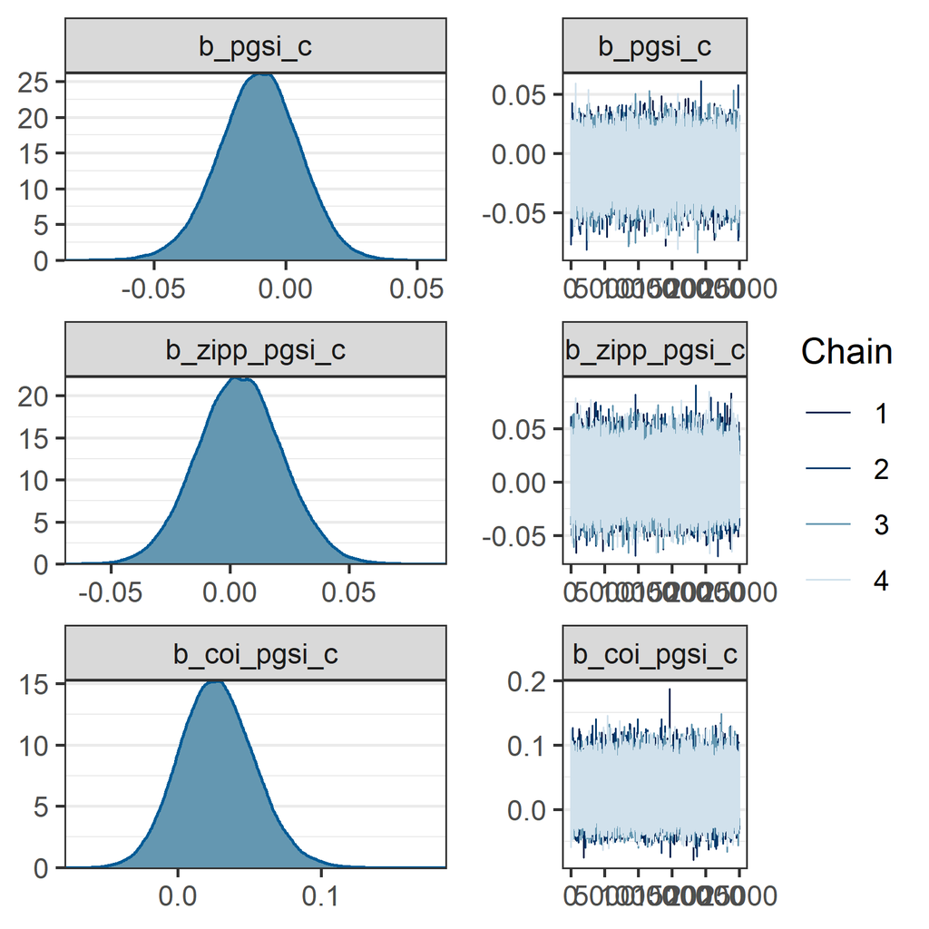

### Plot of Relationships and BANOVA

```
##
##      none      some       all
## 0.3938185 0.1874377 0.4187438
```

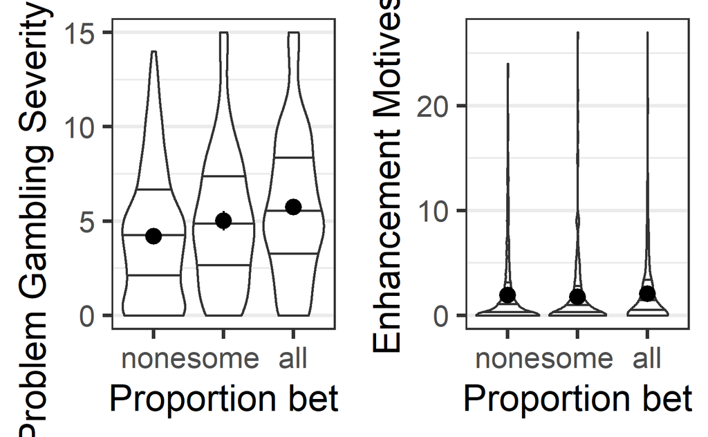

```
## Bayes factor analysis
## --------------
## [1] condition                                     : 0.1672002   ±0.01%
## [2] gamble_cat                                    : 0.01975068  ±0.03%
## [3] condition + gamble_cat                        : 0.003473057 ±1.73%
## [4] condition + gamble_cat + condition:gamble_cat : 0.000118435 ±2.75%
##
## Against denominator:
##   Intercept only
## ---
## Bayes factor type: BFlinearModel, JZS
```

```
##             denominator
## numerator    condition gamble_cat condition + gamble_cat condition + gamble_cat + condition:gamble_cat
##   gamble_cat 0.1181259          1               5.686829                                      166.7638
```

```
## Bayes factor analysis
## --------------
## [1] condition                                     : 0.465961 ±0%
## [2] gamble_cat                                    : 732922.3 ±0.03%
## [3] condition + gamble_cat                        : 502911   ±1.19%
## [4] condition + gamble_cat + condition:gamble_cat : 21071.36 ±2.08%
##
## Against denominator:
##   Intercept only
## ---
## Bayes factor type: BFlinearModel, JZS
```

```
##             denominator
## numerator    condition gamble_cat condition + gamble_cat condition + gamble_cat + condition:gamble_cat
##   gamble_cat   1572927          1                1.45736                                      34.78287
```

## Model With Interactions

```
##  Family: zoib2
##   Links: mu = logit; phi = log; zipp = logit; coi = logit
## Formula: new_prop ~ condition * (pgsi_c + motives_c)
##          phi ~ 1
##          zipp ~ condition * (pgsi_c + motives_c)
##          coi ~ condition * (pgsi_c + motives_c)
##    Data: part2 (Number of observations: 1003)
## Samples: 4 chains, each with iter = 26000; warmup = 1000; thin = 1;
##          total post-warmup samples = 1e+05
##
## Population-Level Effects:
##                                Estimate Est.Error l-95% CI u-95% CI Rhat Bulk_ESS Tail_ESS
## Intercept                         -0.40      0.07    -0.55    -0.26 1.00   157962    75146
## phi_Intercept                      1.88      0.10     1.68     2.07 1.00   152251    75668
## zipp_Intercept                     0.41      0.09     0.23     0.59 1.00   165528    72774
## coi_Intercept                      0.65      0.12     0.41     0.90 1.00   152898    77306
## conditionYellow                    0.04      0.11    -0.18     0.25 1.00   154751    74724
## pgsi_c                            -0.05      0.02    -0.09    -0.00 1.00   118785    77526
## motives_c                          0.01      0.02    -0.03     0.05 1.00   125126    83471
## conditionYellow:pgsi_c             0.03      0.03    -0.03     0.09 1.00   115938    77632
## conditionYellow:motives_c          0.09      0.03     0.02     0.15 1.00   122296    81182
## zipp_conditionYellow               0.10      0.13    -0.16     0.36 1.00   163305    75921
## zipp_pgsi_c                       -0.05      0.03    -0.10    -0.00 1.00   112840    81336
## zipp_motives_c                     0.12      0.03     0.06     0.17 1.00   108757    79144
## zipp_conditionYellow:pgsi_c        0.03      0.04    -0.05     0.11 1.00   114286    82092
## zipp_conditionYellow:motives_c     0.01      0.04    -0.08     0.09 1.00   110144    81188
## coi_conditionYellow                0.29      0.18    -0.06     0.64 1.00   154348    76228
## coi_pgsi_c                         0.02      0.04    -0.05     0.10 1.00   113697    79555
## coi_motives_c                      0.03      0.04    -0.04     0.10 1.00   111206    80948
## coi_conditionYellow:pgsi_c        -0.02      0.06    -0.13     0.09 1.00   114674    80541
## coi_conditionYellow:motives_c      0.05      0.05    -0.05     0.15 1.00   112187    82474
##
## Samples were drawn using sampling(NUTS). For each parameter, Bulk_ESS
## and Tail_ESS are effective sample size measures, and Rhat is the potential
## scale reduction factor on split chains (at convergence, Rhat = 1).
```

As a visual convergence check, we plot the density and trace plots for the four intercept parameters representing the no message condition or the overall mean (for `phi`).

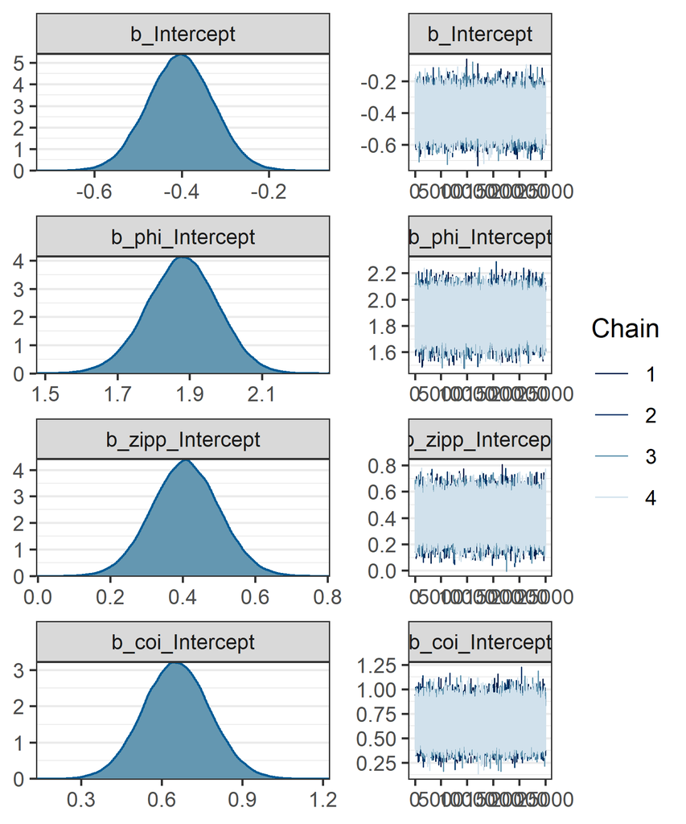

We can also plot the three parameters showing the difference distribution of the yellow message condition from the no messafe condition. These differences are given on the logit scale.

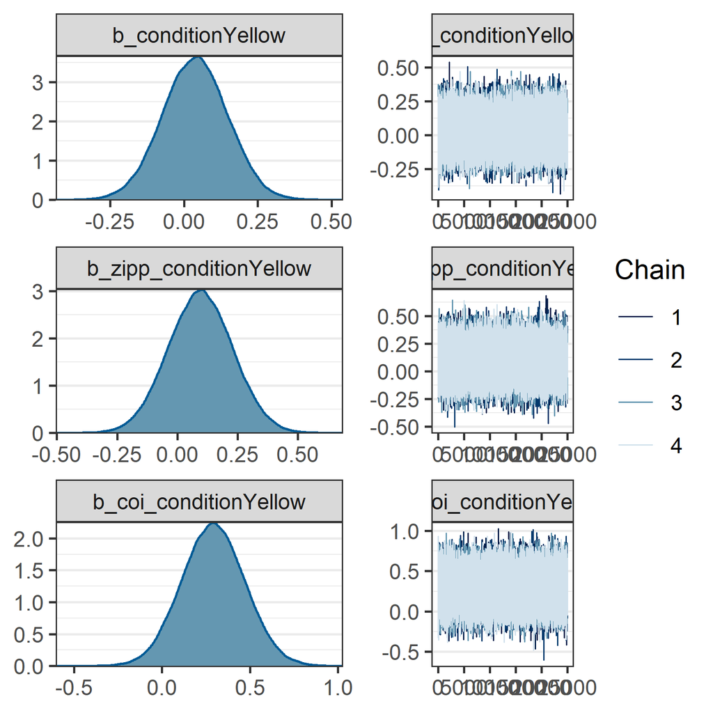

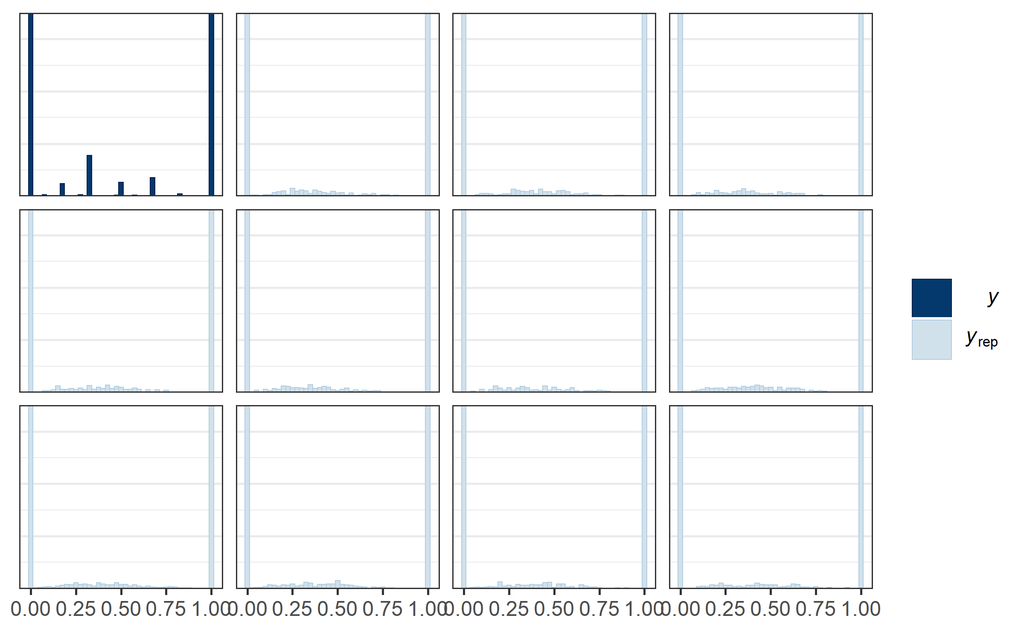

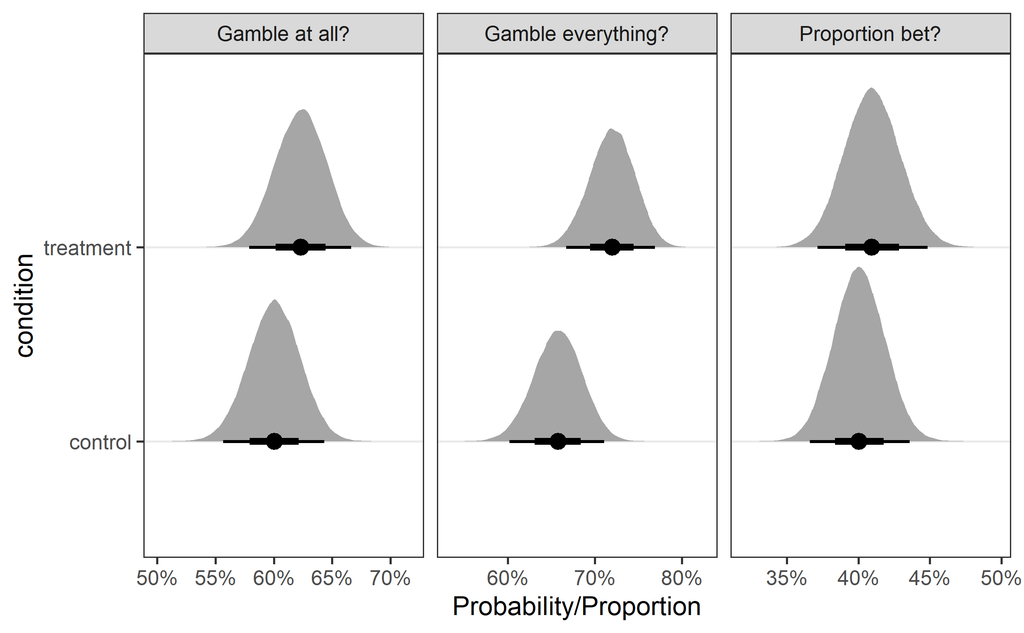

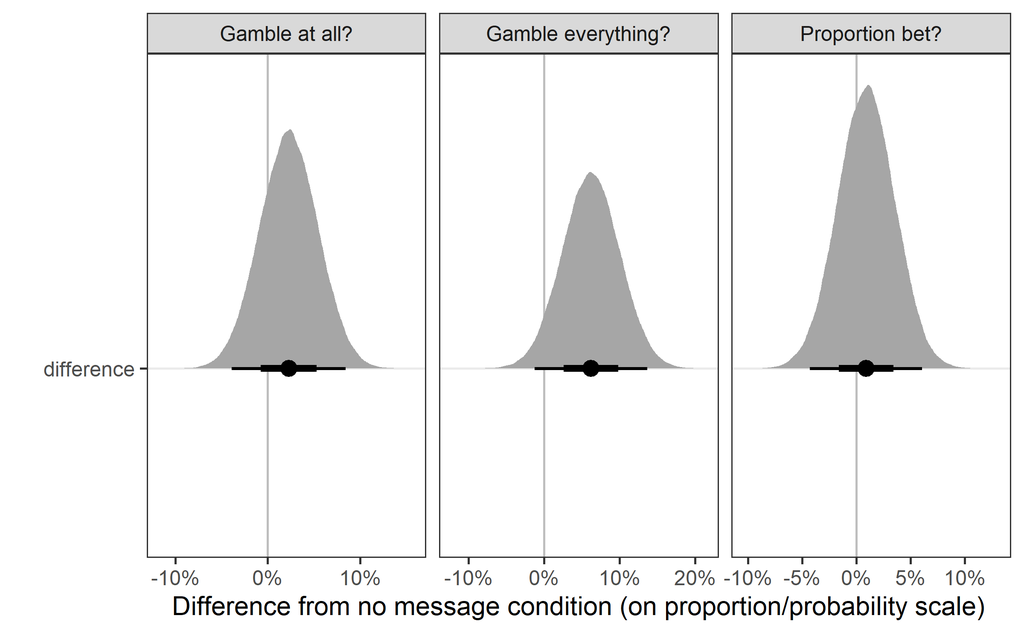

## Model With Interactions (only PGSI)

```
##  Family: zoib2
##   Links: mu = logit; phi = log; zipp = logit; coi = logit
## Formula: new_prop ~ condition * (pgsi_c)
##          phi ~ 1
##          zipp ~ condition * (pgsi_c)
##          coi ~ condition * (pgsi_c)
##    Data: part2 (Number of observations: 1003)
## Samples: 4 chains, each with iter = 26000; warmup = 1000; thin = 1;
##          total post-warmup samples = 1e+05
##
## Population-Level Effects:
##                             Estimate Est.Error l-95% CI u-95% CI Rhat Bulk_ESS Tail_ESS
## Intercept                      -0.39      0.08    -0.54    -0.24 1.00   142224    78453
## phi_Intercept                   1.82      0.10     1.62     2.00 1.00   128555    79050
## zipp_Intercept                  0.41      0.09     0.23     0.59 1.00   131718    75828
## coi_Intercept                   0.67      0.12     0.43     0.91 1.00   131706    80557
## conditionYellow                -0.01      0.11    -0.23     0.21 1.00   132020    77502
## pgsi_c                         -0.04      0.02    -0.09    -0.00 1.00    88573    71395
## conditionYellow:pgsi_c          0.06      0.03     0.01     0.12 1.00    88715    74078
## zipp_conditionYellow            0.05      0.13    -0.20     0.31 1.00   129867    77496
## zipp_pgsi_c                    -0.01      0.02    -0.06     0.04 1.00    93322    76809
## zipp_conditionYellow:pgsi_c     0.04      0.04    -0.04     0.11 1.00    92163    76720
## coi_conditionYellow             0.28      0.18    -0.07     0.63 1.00   117684    74900
## coi_pgsi_c                      0.03      0.04    -0.04     0.11 1.00    86101    71033
## coi_conditionYellow:pgsi_c     -0.01      0.05    -0.11     0.10 1.00    85775    75271
##
## Samples were drawn using sampling(NUTS). For each parameter, Bulk_ESS
## and Tail_ESS are effective sample size measures, and Rhat is the potential
## scale reduction factor on split chains (at convergence, Rhat = 1).
```

As a visual convergence check, we plot the density and trace plots for the four intercept parameters representing the no message condition or the overall mean (for `phi`).

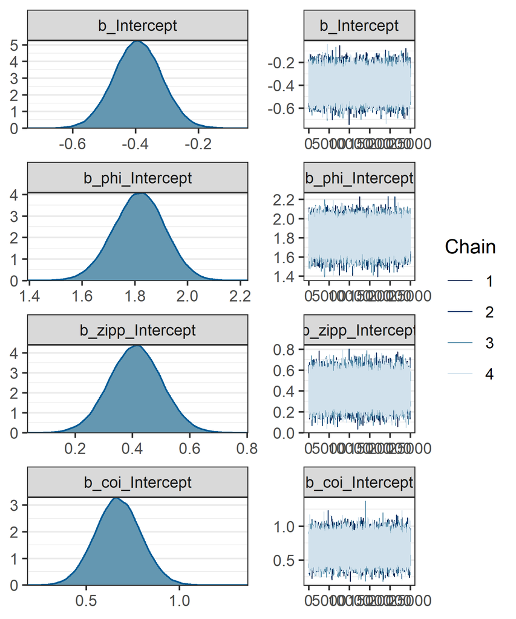

We can also plot the three parameters showing the difference distribution of the yellow message condition from the no message condition. These differences are given on the logit scale.

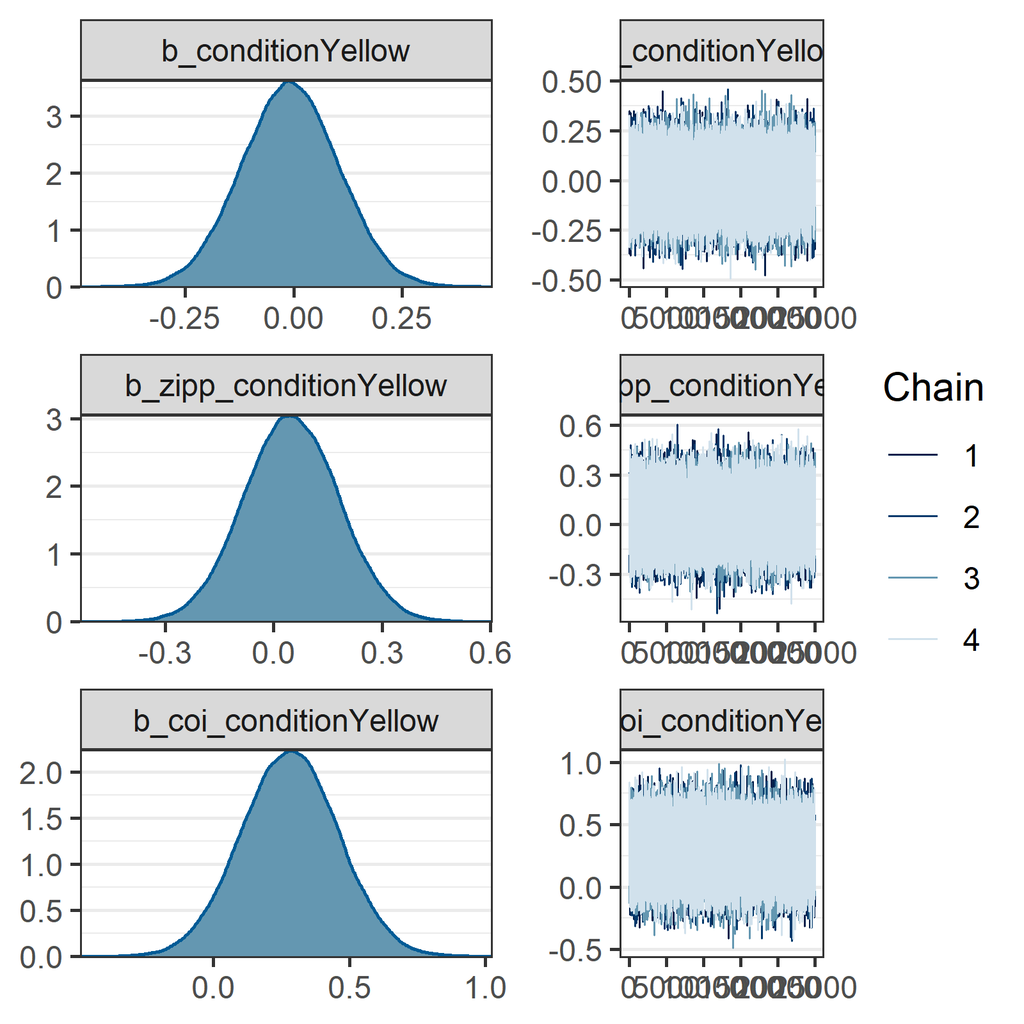

Is the overall effect of PGSI credibly negative?

```
## # A tibble: 2 x 7
##   condition  .value  .lower   .upper .width .point .interval
##   <fct>       <dbl>   <dbl>    <dbl>  <dbl> <chr>  <chr>
## 1 None      -0.0418 -0.0870 -0.00108   0.95 median qi
## 2 Yellow     0.0221 -0.0187  0.0622    0.95 median qi
```

```
## # A tibble: 1 x 6
##    Overall  .lower .upper .width .point .interval
##      <dbl>   <dbl>  <dbl>  <dbl> <chr>  <chr>
## 1 -0.00999 -0.0403 0.0189   0.95 median qi
```

# Riskiness

For the analysis of riskiness, we had to exclude all participants that did not place a single bet. This led to the following N:

```
## # A tibble: 2 x 2
##   condition     n
##   <fct>     <int>
## 1 None        301
## 2 Yellow      307
```

The distribution of riskiness is:

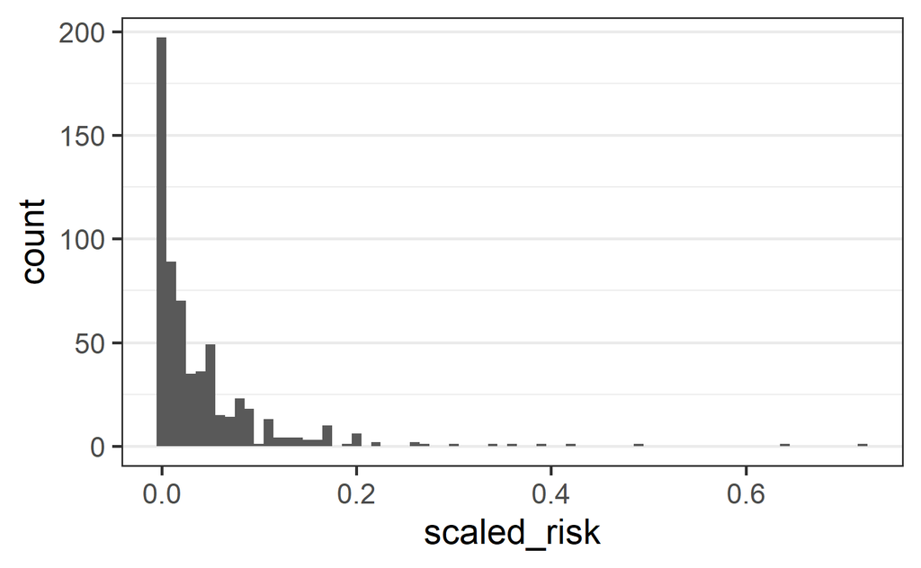

It turns out that there are two participants with a scaled riskiness of zero, both in the treatment condition. And no participants with a riskiness of 1.

```
## # A tibble: 2 x 3
##   condition n_zero n_one
##   <fct>      <int> <int>
## 1 None           0     0
## 2 Yellow         2     0
```

## Beta-Regression

We run the first analysis, using a beta-regression model, after excluding the two zeros.

The model does not show any obvious problems. In addition, we can see that the 95%-CI for the gambling message specific effect includes 0.

```
##  Family: beta
##   Links: mu = logit; phi = log
## Formula: scaled_risk ~ condition
##          phi ~ 1
##    Data: risk3 (Number of observations: 606)
## Samples: 4 chains, each with iter = 2000; warmup = 1000; thin = 1;
##          total post-warmup samples = 4000
##
## Population-Level Effects:
##                 Estimate Est.Error l-95% CI u-95% CI Rhat Bulk_ESS Tail_ESS
## Intercept          -3.07      0.07    -3.20    -2.93 1.00     2148     2383
## phi_Intercept       2.30      0.07     2.15     2.45 1.00     1880     2484
## conditionYellow    -0.10      0.08    -0.25     0.05 1.00     2676     2545
##
## Samples were drawn using sampling(NUTS). For each parameter, Bulk_ESS
## and Tail_ESS are effective sample size measures, and Rhat is the potential
## scale reduction factor on split chains (at convergence, Rhat = 1).
```

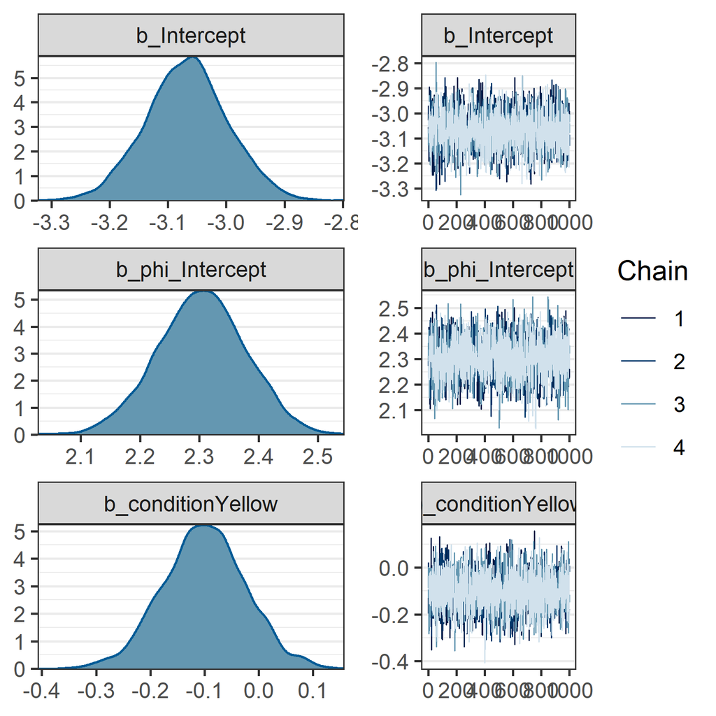

The data and the posterior predictive distribution look good.

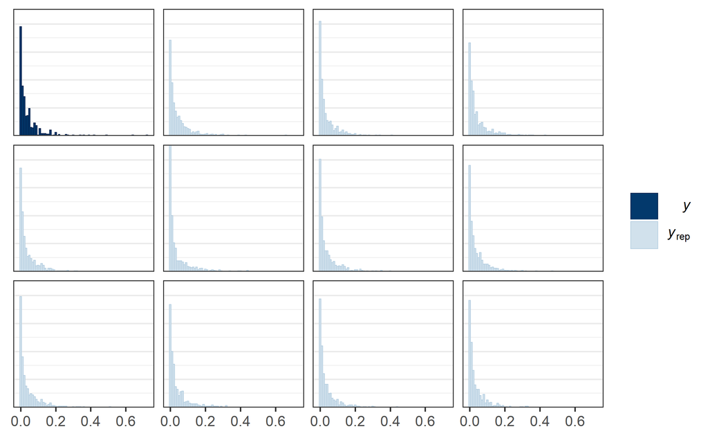

## Zero-Inflated Beta-Regression

We re-run the analysis, using a zero-inflated beta-regression model.

The model also does not show any obvious problems. As above, the 95% CIs of the condition effects contain 0 indicated no evidence that the warning label affects the riskiness of gambles.

```
##  Family: zero_inflated_beta
##   Links: mu = logit; phi = log; zi = logit
## Formula: scaled_risk ~ condition
##          zi ~ condition
##          phi ~ 1
##    Data: risk2 (Number of observations: 608)
## Samples: 4 chains, each with iter = 2000; warmup = 1000; thin = 1;
##          total post-warmup samples = 4000
##
## Population-Level Effects:
##                    Estimate Est.Error l-95% CI u-95% CI Rhat Bulk_ESS Tail_ESS
## Intercept             -3.06      0.07    -3.20    -2.93 1.00     2189     2274
## phi_Intercept          2.30      0.07     2.16     2.44 1.00     1954     1771
## zi_Intercept          -7.67      2.17   -13.16    -4.82 1.00     1510     1087
## conditionYellow       -0.10      0.08    -0.26     0.06 1.00     2610     2452
## zi_conditionYellow     2.67      2.27    -0.71     8.28 1.00     1466     1165
##
## Samples were drawn using sampling(NUTS). For each parameter, Bulk_ESS
## and Tail_ESS are effective sample size measures, and Rhat is the potential
## scale reduction factor on split chains (at convergence, Rhat = 1).
```

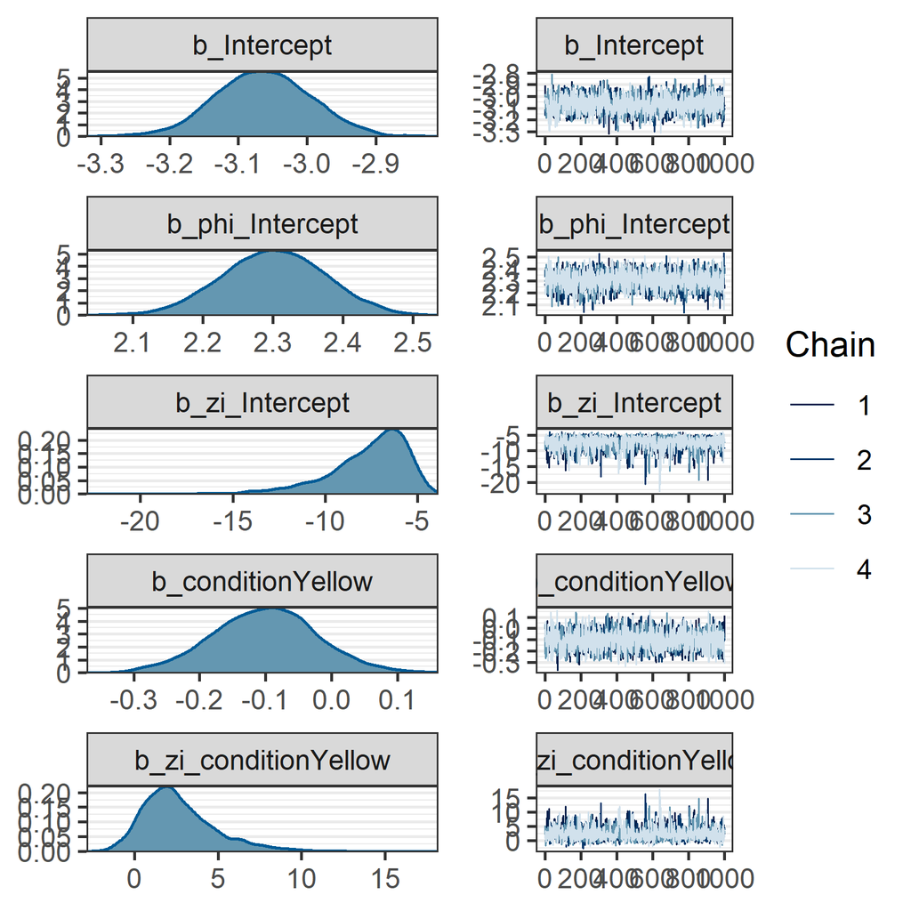

As expected, the data and the posterior predictive distribution also look good.

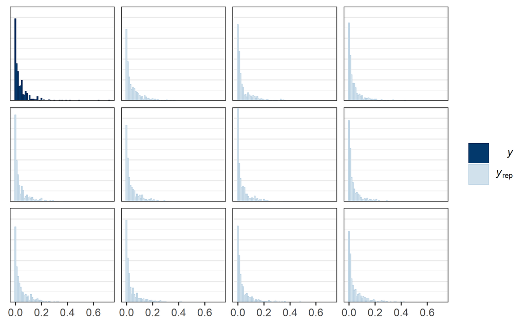